# SingleCell of pancreas tissue

PopovMD

2025-09-14

## SingleCell data analysis

I was given these files [FACS data from mice tissues]:  
https://figshare.com/articles/dataset/Single-cell_RNA-seq_data_from_Smart-seq2_sequencing_of_FACS_sorted_cells/5715040?file=10039267  
to perform these sequence of actions [SingleCell analysis]:  
https://docs.google.com/document/d/1FUbsBUp7Kqh9BeqQ81wVuHGu4mAc6P8mC6l4VR75LKk/edit?tab=t.0#heading=h.ghk5t6a6l7dx.

Script files could be found in the same folder, where you found this .Rmd.

After downloading all necessary files, googling some information about the biological methods and choosing tissue with two subtissues (pancreas), I hopped right to the analysis pipeline.

### Creating Seurat object

```r
library(dplyr)
library(Seurat)
library(patchwork)
library(Matrix)
```

```r
# creating a Seurat Object out of csv table of raw counts for pancreas tissue
raw_counts <- read.csv(file = "./pancreas.raw.counts/Pancreas-counts.csv",
                       sep = ",", header = TRUE, row.names = 1)
colnames(raw_counts) <- gsub("\\.", '_', colnames(raw_counts))
sparse_counts <- as.sparse(as.matrix(raw_counts))
pancr <- CreateSeuratObject(counts = sparse_counts,
                            min.cells = 3,
                            min.features = 200,
                            names.field = 5, # creating clusters by gender: M and F
                            project = "pancreas")
```

```r
head(pancr@meta.data, 10)
```

```
##                         orig.ident nCount_RNA nFeature_RNA
## B21_MAA000574_3_8_M_1_1          M    4932310         2854
## D12_MAA000574_3_8_M_1_1          M    1139900          346
## B22_MAA000574_3_8_M_1_1          M    5790505         2521
## D13_MAA000574_3_8_M_1_1          M    1986467         4166
## C1_MAA000574_3_8_M_1_1           M     525766          229
## D14_MAA000574_3_8_M_1_1          M    1285236         1477
## C2_MAA000574_3_8_M_1_1           M    3738011         4675
## C4_MAA000574_3_8_M_1_1           M     901004          455
## A1_MAA000574_3_8_M_1_1           M      18537          914
## C5_MAA000574_3_8_M_1_1           M     927464         1097
```

### QC and cells selection

```r
# adding a new column to the meta.data, that contains the persantage of reads
# that map to the mitochondrial genome (by using [[ ]]).
pancr[["percent.mt"]] <- PercentageFeatureSet(pancr, pattern = "^MT-")
head(pancr@meta.data, 5)
```

```
##                         orig.ident nCount_RNA nFeature_RNA percent.mt
## B21_MAA000574_3_8_M_1_1          M    4932310         2854          0
## D12_MAA000574_3_8_M_1_1          M    1139900          346          0
## B22_MAA000574_3_8_M_1_1          M    5790505         2521          0
## D13_MAA000574_3_8_M_1_1          M    1986467         4166          0
## C1_MAA000574_3_8_M_1_1           M     525766          229          0
```

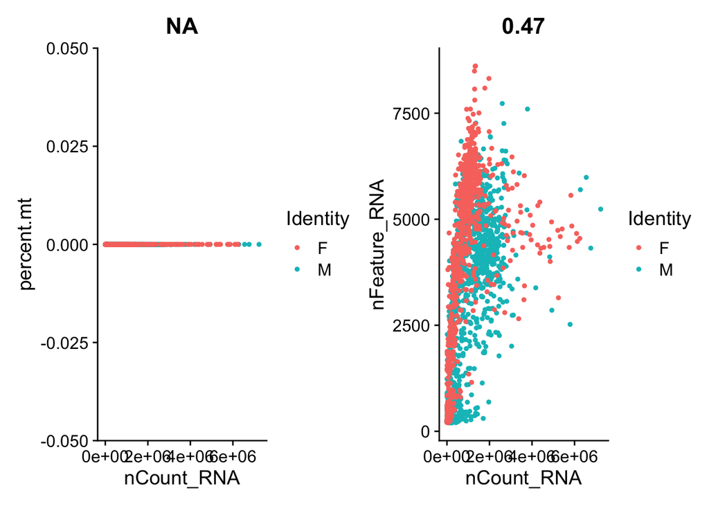

```r
plot1 <- FeatureScatter(pancr, feature1 = "nCount_RNA", feature2 = "percent.mt")
plot2 <- FeatureScatter(pancr, feature1 = "nCount_RNA", feature2 = "nFeature_RNA")
plot1 + plot2
```

```r
sum(pancr@meta.data$percent.mt != 0) # = 0
```

```
## [1] 0
```

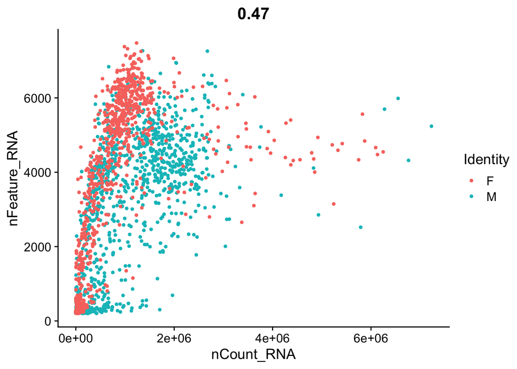

```r
# removing samples with less than 200 genes and more that 7500:
pancr <- subset(pancr, subset = nFeature_RNA > 200 & nFeature_RNA < 7500)
# maybe it makes sense to remove samples with too many reads

FeatureScatter(pancr, feature1 = "nCount_RNA", feature2 = "nFeature_RNA")
```

### Normalizing

```r
pancr_norm <- NormalizeData(pancr, normalization.method = "LogNormalize", scale.factor = 10000)
```

LogNormalize method: normalizing by total expression, multiplying by scale.factor and then log-transforms the result.  
Assumption: each cell originally contains the same number of RNA molecules.

### Selection of highly variable features

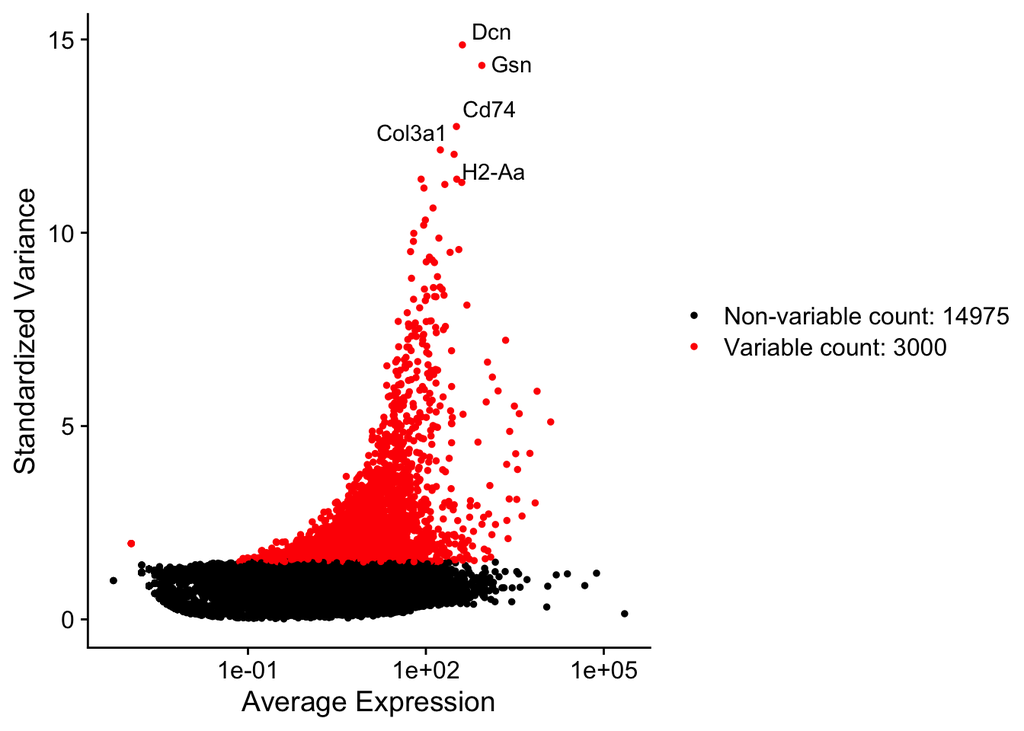

```r
pancr_norm_varfeat <- FindVariableFeatures(pancr_norm,
                                           selection.method = "vst",
                                           nfeatures = 3000)
plot1 <- VariableFeaturePlot(pancr_norm_varfeat)

top10 <- head(VariableFeatures(pancr_norm_varfeat), 5)
LabelPoints(plot = plot1, points = top10, repel = TRUE)
```

### Linear transformation of the data:

```r
all.genes <- rownames(pancr_norm_varfeat)
# transforming all of the genes, not only variable
pancr_linear <- ScaleData(pancr_norm_varfeat, features = all.genes)
```

### Performing linear dimensional reduction

Constructing PCA.

```r
# using only variable features, determined previously (by default)
pancr_linear <- RunPCA(pancr_linear)
print(pancr_linear[['pca']], nfeatures = 6)
```

```
## PC_ 1
## Positive:  Ttr, 1700086L19Rik, Gc, Tmsb15b2, Dbpht2, G6pc2
## Negative:  Sparc, Timp3, Crip2, Ifitm3, Eng, Col4a2
## PC_ 2
## Positive:  Eng, Nrp1, Cd34, Plvap, Sparcl1, Flt1
## Negative:  Spp1, Ces1d, Krt8, Dcdc2a, Cldn3, Krt19
## PC_ 3
## Positive:  Col6a2, Col6a1, Lum, Htra3, Islr, Col1a2
## Negative:  Flt1, Pecam1, Emcn, Kdr, Plvap, Tmem88
## PC_ 4
## Positive:  Igfbp7, Tsc22d1, Col4a1, Ppap2b, Col4a2, Ltbp4
## Negative:  Ctss, Tyrobp, Laptm5, H2-Aa, H2-Ab1, Fcer1g
## PC_ 5
## Positive:  Cela2a, Prss2, Ctrb1, Try4, Clps, 2210010C04Rik
## Negative:  Psap, Fos, 1700086L19Rik, Pld3, Gpx3, Ttr
```

For the first principal components, Seurat outputs a list of genes with the most positive and negative loadings (correlation coefficients), representing modules of genes that exhibit either correlation (or anti-correlation) across single-cells in the dataset.

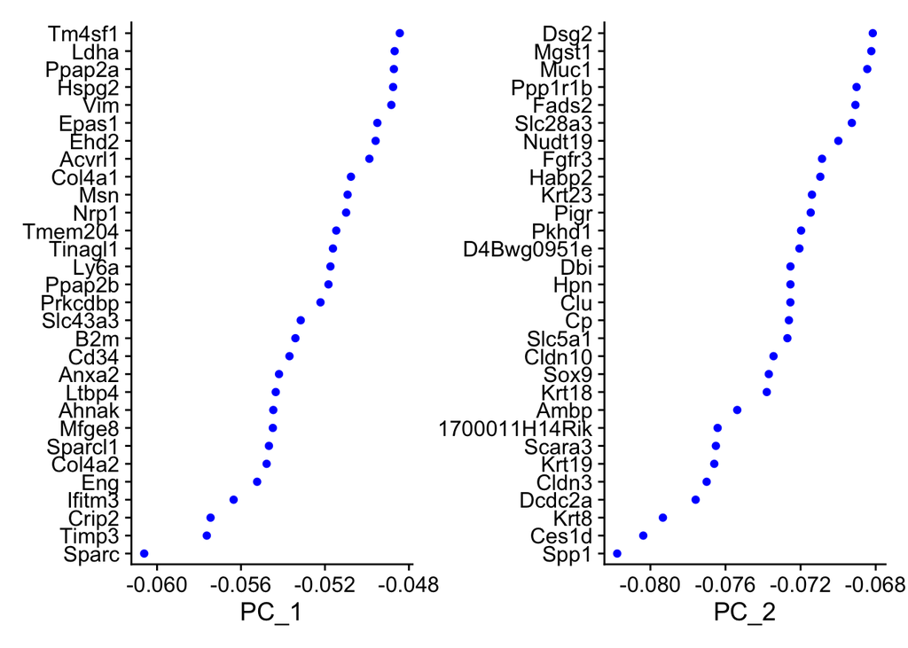

```r
VizDimLoadings(pancr_linear, dims = 1:2, reduction = "pca")
```

The above graph shows, that the data is not really heterogeneous.

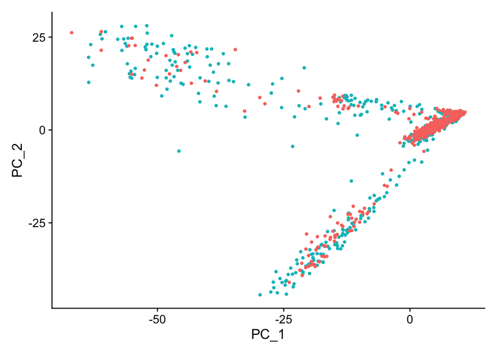

```r
DimPlot(pancr_linear, reduction = "pca") + NoLegend()
```

By this standard PCA picture we can appreciate, that the difference in transcription products for males and females is not that big.

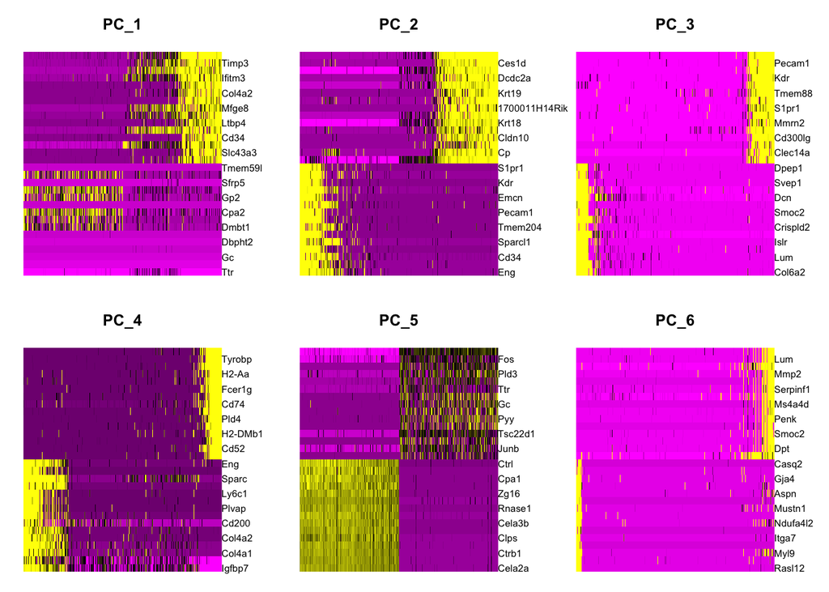

```r
DimHeatmap(pancr_linear, dims = 1:6, cells = 500, balanced = TRUE)
```

And this plot gives us an opportunity to find out, which genes are responsible the most for defining the first 6 principal components.

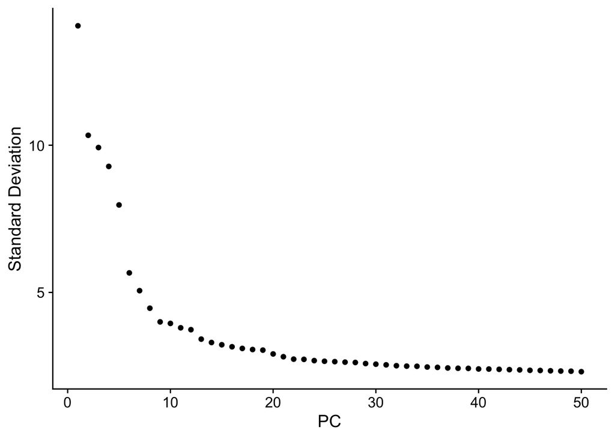

```r
# Choosing the number of principal components by percentage of variance explained by each one
ElbowPlot(pancr_linear, ndims = 50)
```

I would say I see the rightest elbow at the point of 23rd PC.

### Clustering the cells

Providing automated clusterization for further needs (using first 23 PCs):

```r
pancr_clust23 <- FindNeighbors(pancr_linear, dims = 1:23)
pancr_clust23 <- FindClusters(pancr_clust23, resolution = 0.4)
```

```
## Modularity Optimizer version 1.3.0 by Ludo Waltman and Nees Jan van Eck
##
## Number of nodes: 1858
## Number of edges: 60233
##
## Running Louvain algorithm...
## Maximum modularity in 10 random starts: 0.9368
## Number of communities: 11
## Elapsed time: 0 seconds
```

```r
head(Idents(pancr_clust23))
```

```
## B21_MAA000574_3_8_M_1_1 D12_MAA000574_3_8_M_1_1 B22_MAA000574_3_8_M_1_1
##                       9                       2                       9
## D13_MAA000574_3_8_M_1_1  C1_MAA000574_3_8_M_1_1 D14_MAA000574_3_8_M_1_1
##                       7                       2                       4
## Levels: 0 1 2 3 4 5 6 7 8 9 10
```

### Non-linear dimensional reduction

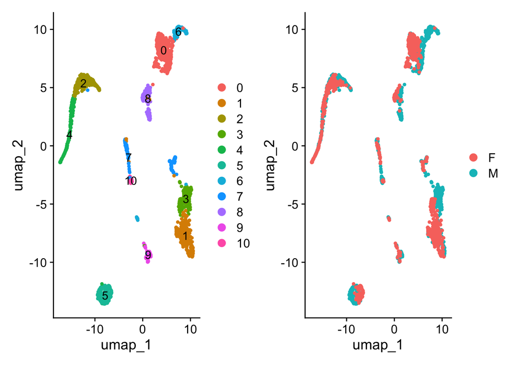

```r
# UMAP for male-female
pancr_linear <- RunUMAP(pancr_linear, dims = 1:23)
umap_M_F_plot <- DimPlot(pancr_linear,
        reduction = "umap")

# UMAP for defined clusters
pancr_clust23 <- RunUMAP(pancr_clust23, dims = 1:23)
umap_clusters_plot <- DimPlot(pancr_clust23,
        reduction = "umap",
        label = TRUE)

umap_clusters_plot + umap_M_F_plot
```

### Creating the bar plot

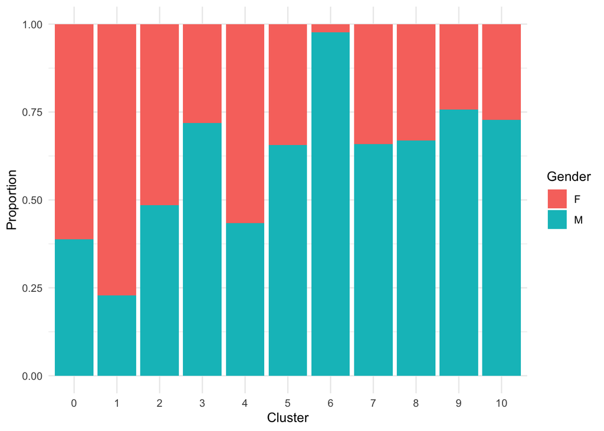

```r
library(ggplot2)

# Bar plot
ggplot(pancr_clust23@meta.data,
       aes(x = Idents(pancr_clust23), fill = pancr_clust23@meta.data$orig.ident)) +
       geom_bar(position = "fill") +
       labs(x = "Cluster", y = "Proportion", fill = "Gender") +
  theme_minimal()
```

### Analysing subtissues

For inserting information about subtissues from metadata file into the count.csv table, I wrote a small python-code. You can find it in the same folder.

[figure not shown]

[figure not shown]

[figure not shown]

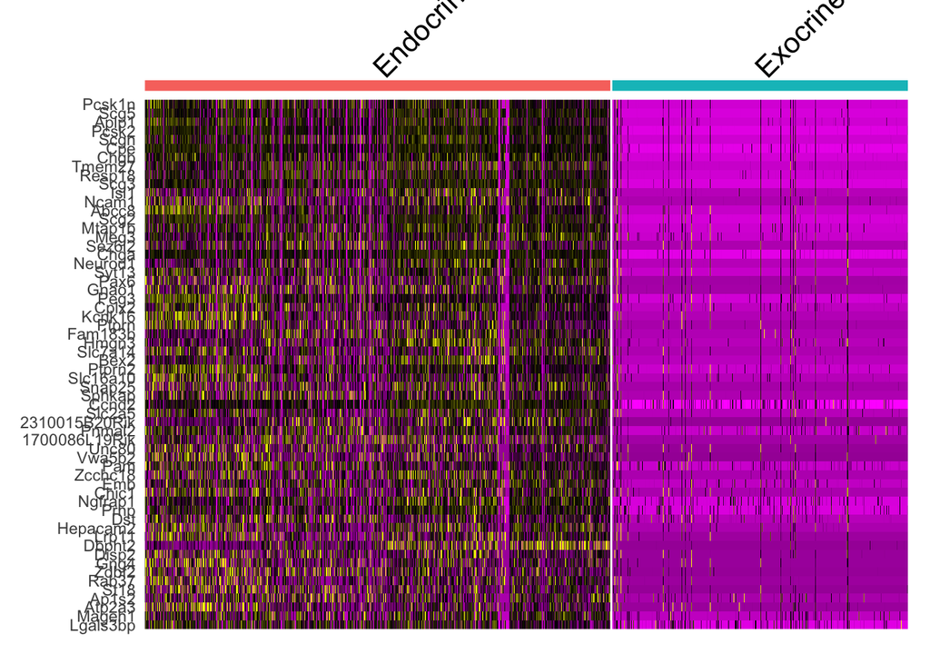

```r
# find all markers (of DE of genes) distinguishing Exocrine class from Endocrine one
clusters.markers <- FindMarkers(pancr_linear,
                                ident.1 = 'Endocrine',
                                ident.2 = 'Exocrine')

clusters.markers %>%
  dplyr::filter(avg_log2FC > 1) %>%
  slice_head(n = 60) %>%
  ungroup() -> top60

# HeatMap
DoHeatmap(pancr_linear, features = row.names(top60)) + NoLegend()
```

Unfortunately, we can not clearly see the separation of two subtissues on the heatmap: it seems like exocrine one is merely above zero rate of expression, however, this plot is not full: it represents only top 60 genes by the expression rate. So, we unintentionally chose only whose genes, which are transcribed mostly in endocrine subtissue.  
Nevertheless, we still can confirm, that by the expression rate of these genes, these subtissues are different.